# Calculating uniqueness

Andrea Ballatore

27/03/2022

# 1 Sandbox

```r
# TODO: handle missing values in dist_uniq with option

# generate matrices
set.seed(50)
unitib = gen_random_matrix('uniform', 1000, 10)
normtib = gen_random_matrix('normal', 8, 3)
gtib = gen_random_matrix('2groups', 20, 3, group_split = .2)
zerotib = gen_const_matrix(8,3,0)
onetib = gen_const_matrix(8,3,1)

gtib = gen_random_matrix('3groups', 100, 5)
ugtib = dist_uniq(gtib, 'euclidean')
desc_stats_uniq(ugtib)

gtib = gen_random_matrix('2groups', 100, 2)
ugtib = dist_uniq(gtib, 'euclidean')
print(desc_stats_uniq(ugtib))

tib = gen_random_matrix('normal', 1000, 5)
ugtib = dist_uniq(tib, 'euclidean')
print(desc_stats_uniq(ugtib))

ugtib = dist_uniq(tib, 'euclidean')
ugtib = dist_uniq(tib, 'mahalanobis')
ugtib = dist_uniq(tib, 'manhattan')
desc_stats_uniq(ugtib)

cov(gen_random_matrix('2groups',100,100))
ugtib = dist_uniq(gen_random_matrix('2groups',100,100), 'mahalanobis')
tib = gen_random_matrix('2groups',100,100)
maha_sum_dists = mahalanobis(tib, colMeans(tib), cov(tib), tol=1e-20)

# test uniqueness
tib = unitib

if (F){
  # scale variables 0 1
  #tib = tib %>% mutate_if(is.numeric, range01)

}
#cos = tcosine(tib)

#mat = gen_random_matrix('normal', 1000, 100)
#bigdist(as.matrix(mat), 'analysis/dist_matrix.tmp', method='euclidean')
#dist_uniq()

#utib$sum_dists_div = sum_dists / nrow(utib)
#utib$sum_dists_log = log10(utib$sum_dists+1)
#utib$sum_dists_sqrt = sqrt(utib$sum_dists)
#n = 3
#utib$sum_dists_nrt = utib$sum_dists ^ (1 / n)
#utib$uniq_lin = 1/(1+utib$sum_dists)
#utib$uniq_log = 1/(1+utib$sum_dists_log)
#utib$uniq_sqrt = 1/(1+utib$sum_dists_sqrt)
#utib$sum_cos = rowSums(cos)
#utib$sum_cos_pos = utib$sum_cos-min(utib$sum_cos)
#utib$sum_cos_log = log10(utib$sum_cos+1)

#View(round(utib,4))
#summary(utib)

# plot histograms
#tib_long <- utib %>% pivot_longer(colnames(utib)) %>% as_tibble()
#gp1 <- ggplot(tib_long, aes(x = value)) +    # Draw each column as histogram
  #geom_histogram(bins = 10) +
#  geom_density(adjust = 1/2) +
#  facet_wrap(~ name, scales = "free_x")
#print(gp1)

# characteristics of uniq to be saved for diagnostic
#x = scale(utib$sum_dists)

#desc_stats(x)
```

# 2 Outlier detection

## 2.1 Univariate OD

This is similar to outlier detection, in the sense of detection of extreme values, and not of measurement errors. For a single variable, there are well-known methods, e.g., boxplots, n StDev, etc.

“Enderlein (1987) goes even further as the author considers outliers as values that deviate so much from other observations one might suppose a different underlying sampling mechanism. … it sometimes makes sense to formally distinguish two classes of outliers: (i) extreme values and (ii) mistakes.” https://statsandr.com/blog/outliers-detection-in-r

## 2.2 Multivariate OD

In a multi-variate context, the outliers we are interested in are *rare combinations of values*. Individually, the values of each variable might not be extreme, but the combination appears relatively far from others.

“The adjusted quantile plot function of the mvoutlier package will solve for and order the squared Mahalanobis Distances for the given observations and plot them against the empirical Chi-Squared distribution function of these values.” https://rpubs.com/Treegonaut/301942

```r
# use mvoutlier
indf = as.data.frame(gen_random_matrix('2groups', 20, 3))

outliers <- aq.plot(indf, delta=qchisq(0.975, df = ncol(indf)))
```

[output not shown]

## 2.3 Mahalanobis distance

The Mahalnobis distance is often used for OD in multivariate data.

“In multivariate space, the Mahalanobis distance is the distance between two points. It’s frequently used to locate outliers in statistical investigations involving several variables.” Source: https://www.r-bloggers.com/2021/08/how-to-calculate-mahalanobis-distance-in-r/

```r
intib = gen_random_matrix('2groups', 10, 4)
intib
```

```
##               V1            V2            V3            V4
## 1    -1.02467024   -1.84677760    -1.3186128   -1.20944889
## 2    -0.07572982    1.77190852    -0.4435143    0.73661065
## 3    -1.93892876    0.06898366     0.3413734    1.48573564
## 4    -0.16137227    1.46660557     1.2693641    0.01016863
## 5    -1.63765442    1.78072988     0.0634555    0.57248807
## 6   993.15471573 -139.04906736  1522.5969787 1054.91395253
## 7     0.17660619   -1.72302341     0.4880035    0.62436370
## 8     1.67404866   -0.52648058     0.2093570    1.05694053
## 9     2.20935128   -0.99117519    -0.2027403   -1.32472439
## 10 -358.81385375  193.14186132 -1185.5930606 1187.58612917
```

```r
# x: input data
# center: indicate the mean vector of the distribution
# cov: indicate the covariance matrix of the distribution
intib$maha_dist = mahalanobis(intib, colMeans(intib), cov(intib))

# The p-value is the Chi-Square statistic of the
# Mahalanobis distance with k-1 degrees of freedom,
# where k is the number of variables.
intib$maha_pvalue <- pchisq(intib$maha_dist, df=ncol(intib), lower.tail=F)
#View(intib)
intib$maha_dist
```

```
##  [1] 2.683941 2.297648 3.226668 1.669035 2.356592 8.099985 2.137689 1.383435
##  [9] 4.045016 8.099990
```

# 3 Uniqueness

## 3.1 Univariate uniqueness

Uniqueness can be thought of as $1 - p$, where p is the probability of encountering a particular observation from random extractions from a set.

For example, these are the percentages of land cover categories in the UK: Farmland 56.7%, Natural 34.9%, Green urban 2.5%, Built on 5.9%. Taking a probabilistic view, we can define the uniqueness of a category as 1-p. The rarest category we would encounter by selecting a random area in the UK is green urban ($U = .98$).

Data source: https://www.eea.europa.eu/publications/COR0-landcover

```r
uk_landcover = tibble(cat=c('farm','natural','green urban','built'), pc=c(56.7, 34.9, 2.5, 5.9))
uk_landcover$p = uk_landcover$pc/100
uk_landcover$uniq = 1 - uk_landcover$p

uk_landcover
```

```
## # A tibble: 4 x 4
##   cat            pc     p  uniq
##   <chr>       <dbl> <dbl> <dbl>
## 1 farm         56.7 0.567 0.433
## 2 natural      34.9 0.349 0.651
## 3 green urban   2.5 0.025 0.975
## 4 built         5.9 0.059 0.941
```

To make it more interpretable, we can use the z score. This way, more unique observations emerge from the data.

```r
uk_landcover$uniq_z = round(zscore(uk_landcover$uniq),2)

uk_landcover
```

```
## # A tibble: 4 x 5
##   cat            pc     p  uniq uniq_z[,1]
##   <chr>       <dbl> <dbl> <dbl>      <dbl>
## 1 farm         56.7 0.567 0.433      -1.24
## 2 natural      34.9 0.349 0.651      -0.39
## 3 green urban   2.5 0.025 0.975       0.88
## 4 built         5.9 0.059 0.941       0.74
```

We can think of uniqueness as a deviation from the uniform distribution. If all types of observation occur at the same probability, it is not possible to calculate a meaningful uniqueness score ($z$ is NA).

```r
uniform_tib = tibble(cat=c('cat1','cat2','cat3','cat4'), pc=1/4, uniq=1-1/4)
uniform_tib$uniq_z = zscore(uniform_tib$uniq)
print(uniform_tib)
```

```
## # A tibble: 4 x 4
##   cat      pc  uniq uniq_z[,1]
##   <chr> <dbl> <dbl>      <dbl>
## 1 cat1   0.25  0.75        NaN
## 2 cat2   0.25  0.75        NaN
## 3 cat3   0.25  0.75        NaN
## 4 cat4   0.25  0.75        NaN
```

We can use measures of entropy to see if the data has heterogeneity that can be used to quantify uniqueness. High entropy means low heterogeneity (no observation will be unique) and vice-versa.

```r
print(paste('Entropy of uniform data', round(entropy(uniform_tib$pc),2)))
```

```
## [1] "Entropy of uniform data 1.39"
```

```r
print(paste('Entropy of heterogeneous data', round(entropy(uk_landcover$pc),2)))
```

```
## [1] "Entropy of heterogeneous data 0.95"
```

## 3.2 Multi-variate uniqueness

The multivariate case is more interesting and challenging. It is useful for exploratory data analysis (EDA).

In this example, we consider four observations along two dimensions. The geometric interpretation of uniqueness of observation $a$ in this case is $u_a = \sum dist(a,b)$. To make the results more interpretable, we can obtain the $z$ scores. It is possible to observe visually that point 1 is the most spatially isolated, while point 2 is the most central to the dataset and therefore has the lowest uniqueness.

### 3.2.1 Minimal example

```r
multiv_tib = as_tibble(matrix(c(-1,0,1,0,-1,0,1,1), ncol = 2))
print(multiv_tib)
```

```
## # A tibble: 4 x 2
##      V1    V2
##   <dbl> <dbl>
## 1    -1    -1
## 2     0     0
## 3     1     1
## 4     0     1
```

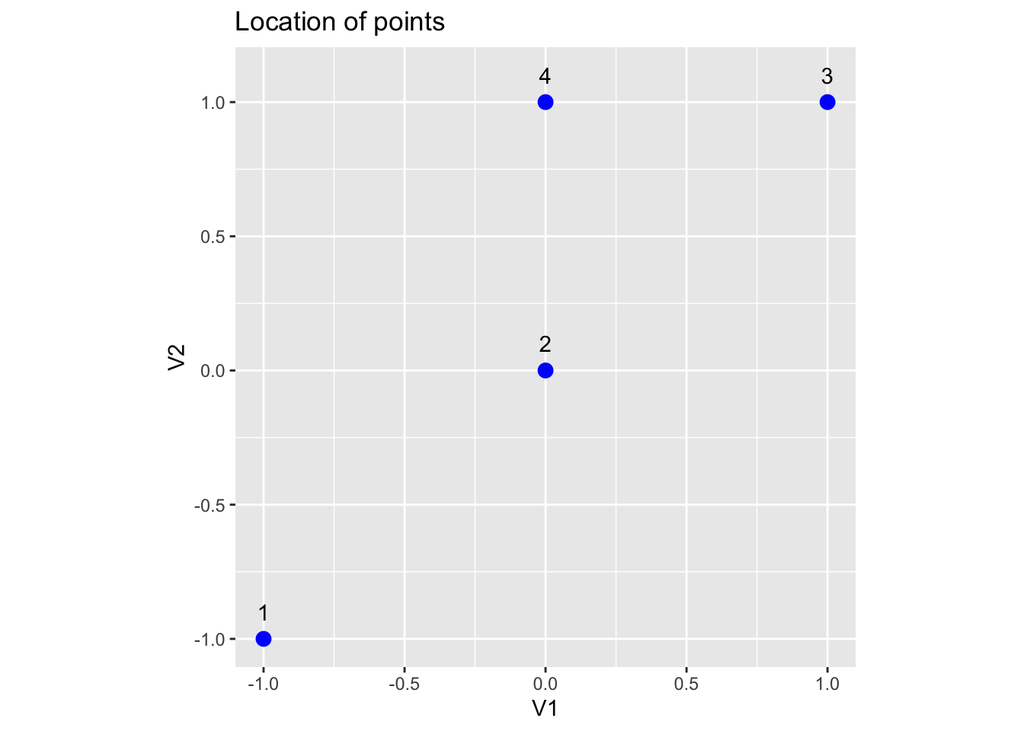

```r
# plot
ggplot(multiv_tib, aes(x=V1, y=V2, label=rownames(multiv_tib))) + theme(aspect.ratio = 1) +
  geom_point(size=3, colour='blue', fill='blue') + geom_text(nudge_y = .1) +
  ggtitle('Location of points')
```

```r
# get distance matrix
dist_mat = as.matrix(dist(multiv_tib, diag = T, upper = T))
print(dist_mat)
```

```
##          1        2        3        4
## 1 0.000000 1.414214 2.828427 2.236068
## 2 1.414214 0.000000 1.414214 1.000000
## 3 2.828427 1.414214 0.000000 1.000000
## 4 2.236068 1.000000 1.000000 0.000000
```

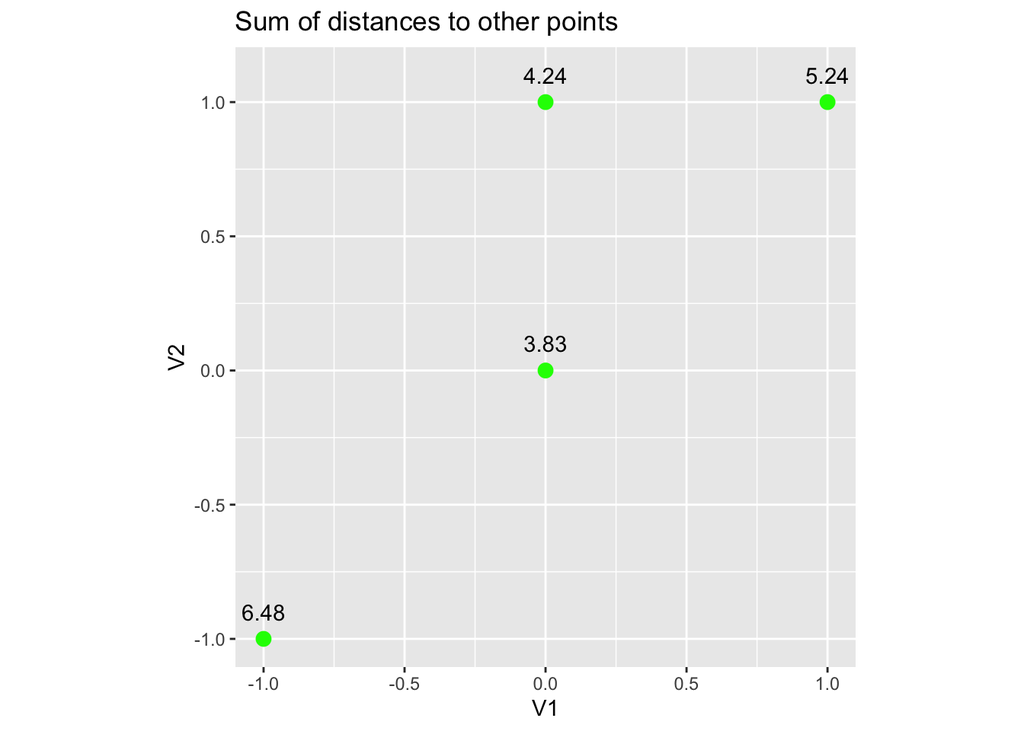

```r
# sum distances
multiv_tib$sum_dist = round(rowSums(dist_mat),2)
multiv_tib$sum_dist_z = round(zscore(multiv_tib$sum_dist),2)

# plot uniqueness
ggplot(multiv_tib, aes(x=V1, y=V2, label=sum_dist)) + theme(aspect.ratio = 1) +
  geom_point(size=3, colour='green', fill='green') + geom_text(nudge_y = .1) +
  ggtitle('Sum of distances to other points')
```

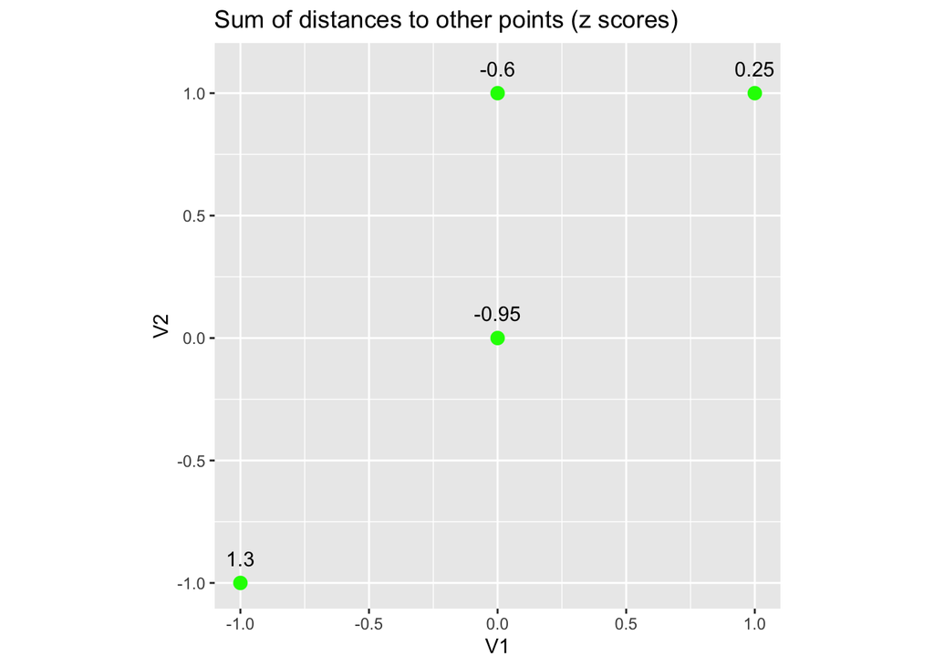

```r
# plot z scores of uniqueness
ggplot(multiv_tib, aes(x=V1, y=V2, label=sum_dist_z)) + theme(aspect.ratio = 1) +
  geom_point(size=3, colour='green', fill='green') + geom_text(nudge_y = .1) +
  ggtitle('Sum of distances to other points (z scores)')
```

### 3.2.2 Distance-based uniq

Define uniqueness functions

```r
#' Descriptive statistics
#' @return tibble with a row with descriptive stats about x (z scores).
desc_stats_uniq <- function(utib){
  x = utib$sum_dists_z
  shap_x = x
  if (nrow(utib) > 5000){
    shap_x = sample(utib, 5000)
  }

  uclasses = table(utib$sum_dists_class)/nrow(utib)*100

  tibble(
    n = length(x),
    min = min(x),
    med = median(x),
    mean = mean(x),
    max = max(x),
    pc_very_common = uclasses['very common'],
    pc_common = uclasses['common'],
    pc_inbet = uclasses['in between'],
    pc_rare = uclasses['rare'],
    pc_very_rare = uclasses['very rare'],
    skewness = round(skewness(x),3),
    iqr = round(IQR(x),3),
    shapiro_w = shapiro.test(shap_x)$stat,
    shapiro_p = round(shapiro.test(shap_x)$p,5)
  )
}

#' Find a sample size to produce a distance matrix that is manageable in memory
find_sample_sz = function(n_row, n_col, max_dist_size){
  while(((n_col*n_row)^2) > max_dist_size){
    n_row = n_row - 1
  }
  return(n_row)
}

#' Classify p values returned by the uniqueness function with a
#' human readable label.
classify_uniq = function(p_values){
  breaks = c(0, .001, .01, .05, .1, Inf)
  labels = c('very rare','rare','in between','common','very common')
  classif = cut(p_values, breaks, labels)
  #print(summary(classif)/length(p_values)*100)
  return(classif)
}

#' Calculate uniqueness based on distance in multi-dimensional space.
#' @param tib
#' @param dist_method
#' @return
dist_uniq = function(tib, dist_method){
  print(paste('dist_uniq', nrow(tib), ncol(tib), dist_method))
  # scale input variables mean + sd
  tib = tib %>% mutate_if(is.numeric, scale)
  stopifnot(dist_method %in% c('euclidean','mahalanobis','manhattan', 'minkowski'))


  # check memory limit for distance matrix
  max_matrix_sz = 1e8
  #print(dim(tib))
  sample_rows = find_sample_sz(nrow(tib), ncol(tib), max_matrix_sz)
  if (nrow(tib) > sample_rows){
    warning(paste("Distance matrix would be too large, using a sample N =",sample_rows))
    tib = tib %>% sample_n(sample_rows)
  }
  # calculate distances
  if (dist_method == 'mahalanobis'){
    # tolerance has to be set to avoid rounding errors
    sum_dists = mahalanobis(tib, colMeans(tib), cov(tib), tol=1e-20)
  } else {
    sum_dists = rowSums(as_tibble(as.matrix(dist(tib,
                    diag = T, upper = T, method = dist_method))))
  }
  utib = tib
  utib$sum_dists = sum_dists
  utib$sum_dists_z = zscore(sum_dists)
  # calculate p value of z score:
  # we are interested to check if an observation is higher than expected (lower.tail=F)
  utib$sum_dists_z_p = pnorm(q=utib$sum_dists_z, mean = mean(utib$sum_dists_z),
                 sd = sd(utib$sum_dists_z), lower.tail=F)
  utib$sum_dists_class = classify_uniq(utib$sum_dists_z_p)
  # discarded p values
  #utib$sum_dists_z_p = 2*pnorm(q=utib$sum_dists_z, lower.tail=FALSE)
  #utib$sum_dists_pvalue <- pchisq(utib$sum_dists_z, df=ncol(tib), lower.tail=F)
  utib$dist_method = dist_method
  as_tibble(utib)
}

#' Main function to calculate uniqueness
#' @tib input data tibble, including numeric and non-numeric columns
#' @return a tibble with results and the similarity matrix between all rows.
OLD_calc_uniqueness = function(tib, sim_method, handle_missing_values=T){
  # get only numeric columns
  indata = tib %>% select_if(is.numeric)
  stopifnot(ncol(indata) > 1)

  stopifnot(sim_method %in% c('cosine', "euclidean", "maximum", "manhattan",
                              "canberra", "binary", "minkowski"))

  # calculate entropy for each row:
  #   high = uniform data, low = some attribute high/low
  #entropies = apply(X = indata, MARGIN = 1, FUN = function(x) entropy(x[!is.na(x)]))

  if (sim_method == 'cosine'){
    # scale columns between 0 and 1
    scaled_indata = indata %>% mutate_if(is.numeric, range01)
    # calculate cosine similarities between rows
    sim_matrix = tcosine(scaled_indata) %>% as_tibble()
  } else {
    stopifnot(sim_method %in% c("euclidean", "maximum", "manhattan", "canberra",
              "binary", "minkowski"))
    # calculate cosine similarities between rows
    edist = dist(indata, diag=T, upper=T, method=sim_method) %>% as.matrix() %>% as_tibble()
    stopifnot(edist >= 0)
    sim_matrix = 1/(1+edist)
  }
  #View(sim_matrix)
  stopifnot(sim_matrix >= 0 & sim_matrix <= 1)

  if (handle_missing_values){
    # calculate cosine for cases with missing values
    missing_cases = rowSums(is.na(sim_matrix))
    missing_cases_row_idx = which(missing_cases == (ncol(sim_matrix)-1))
    #print(paste0('Missing cases N = ', length(missing_cases_row_idx)))
    for (row_idx in missing_cases_row_idx){
      for (other_row_idx in seq(nrow(indata))){
        non_null_pair = indata[c(row_idx,other_row_idx),] %>%
          select_if(is.numeric) %>% select_if(~ !any(is.na(.)))
        n_pair_vars = ncol(non_null_pair)
        pair_cosine = tcosine(non_null_pair)
        sim_matrix[row_idx, other_row_idx] = pair_cosine[1,2]
        sim_matrix[other_row_idx, row_idx] = pair_cosine[2,1]
      }
    }
  }
  uniq_df = tib
  uniq_df$na_count = rowSums(is.na(indata))
  # calculate uniqueness
  uniq_df$sim_sum = rowSums(sim_matrix, na.rm=T)-1
  uniq_df$sim_sum[uniq_df$sim_sum == 0] <- NA
  uniq_df$uniq = 1 - (uniq_df$sim_sum / nrow(uniq_df))
  uniq_df$uniq_rank = rank(-uniq_df$uniq)
  uniq_df$uniq_z = z_score(uniq_df$uniq)
  uniq_df$uniq_dist_avg = uniq_df$uniq - mean(uniq_df$uniq)
  # save entropy in results
  #uniq_df$entropy = entropies
  #View(uniq_df)
  #print(summary(uniq_df$uniq))
  stopifnot(uniq_df$uniq >= 0 & uniq_df$uniq <= 1)
  return(list(uniqueness=uniq_df, sim_matrix=sim_matrix))
}
```

### 3.2.3 Experiment with high dim

On high dimensional data, the interpretation of $u$ is less immediate. Therefore, it is useful to observe the behaviour of the uniqueness measure $u$ through a Monte Carlo method.

#### 3.2.3.1 Generate synth data

```r
#t = gen_random_matrix('normal', 10, 5)
#u = calc_uniqueness(t, 'euclidean')
#View(u$uniqueness)
#ggplot(u$uniqueness, aes(x=uniq_dist_avg)) + xlab("uniq_dist_avg") +
#  geom_histogram(color="white", fill="lightgreen", bins = 10)#
#ggplot(u$uniqueness, aes(x=uniq)) + #xlab("uniq_dist_avg") +
#  geom_histogram(color="white", fill="gray", bins = 10)

if (T){
  # synthetic data
  res = tibble()
  set.seed(NULL)
  for (rand_data in c('normal','uniform','2groups','3groups'))
  for (dist_method in c('euclidean','manhattan','minkowski','mahalanobis'))
  for (data_scale in c(1,100,1000))
  for (row_n in c(10,100,1000,10000))
  for (col_n in c(2,10,20))
  for (trial in seq(10))
  {
    if (row_n == 0 | col_n == 0) next()
    #if (dist_method != 'mahalanobis') next()
    rand_tib = gen_random_matrix(rand_data, row_n, col_n, data_scale)
    utib = dist_uniq(rand_tib, dist_method)
    res_row = desc_stats_uniq(utib)
    res_row = res_row %>% add_column(distrib = rand_data,
                             dist_method = dist_method,
                             data_scale = data_scale,
                             row_n = row_n,
                             col_n = col_n,
                             sample_n = nrow(utib),
                             trial = trial,
                             .before = "n")
    res = bind_rows(res, res_row)
  }

  saveRDS(res, 'analysis/high_dimensional_experiment_1.rds')
  openxlsx::write.xlsx(res, 'analysis/high_dimensional_experiment_1.xlsx')
}
```

#### 3.2.3.2 Analyse results

Summarise experiment 1 results to observe trends in $u$ in different settings.

```r
res_tib = readRDS('analysis/high_dimensional_experiment_1.rds')
  #%>% #mutate_if(is.character, factor)
print(nrow(res_tib))
```

```
## [1] 5760
```

```r
summary_res = tibble()

for (cols in list(c('row_n'), c('col_n'),
    c('distrib','row_n'), c('distrib','col_n'), c('distrib'),
    c('dist_method'), c('data_scale'),
    c('distrib','dist_method'),
    c('distrib','dist_method','data_scale'))){
  print(cols)
  cols_str = paste(cols, collapse = ' ')
  res_stats_tib = res_tib %>%
    #group_by(distrib, dist_method) %>%
    group_by(across(all_of(cols))) %>%  # all_of
    dplyr::summarise(cols = cols_str,
      n = n(),
      mn_dist_min = mean(min),
      mn_dist_max = mean(max),
      mn_vcommon = mean(pc_very_common),
      mn_common = mean(pc_common),
      mn_inbet = mean(pc_inbet),
      mn_rare = mean(pc_rare),
      mn_vrare = mean(pc_very_rare),
      mn_skew = mean(skewness)) %>%
    mutate_if(is.numeric, round, 2)

  summary_res = bind_rows(summary_res, res_stats_tib)
}
```

```
## [1] "row_n"
## [1] "col_n"
## [1] "distrib" "row_n"
```

```
## `mutate_if()` ignored the following grouping variables:
## Column `distrib`
```

```
## [1] "distrib" "col_n"
```

```
## `mutate_if()` ignored the following grouping variables:
## Column `distrib`
```

```
## [1] "distrib"
## [1] "dist_method"
## [1] "data_scale"
## [1] "distrib"     "dist_method"
```

```
## `mutate_if()` ignored the following grouping variables:
## Column `distrib`
```

```
## [1] "distrib"     "dist_method" "data_scale"
```

```
## `mutate_if()` ignored the following grouping variables:
## Columns `distrib`, `dist_method`
```

```r
summary_res
```

```
## # A tibble: 110 x 15
##    row_n cols            n mn_dist_min mn_dist_max mn_vcommon mn_common mn_inbet
##    <dbl> <chr>       <dbl>       <dbl>       <dbl>      <dbl>     <dbl>    <dbl>
##  1    10 row_n        1440       -1.03        2.01       87.9      3.38     5.68
##  2   100 row_n        1440       -1.16        3.37       88.3      3.17     4.77
##  3  1000 row_n        1440       -1.28        4.58       88.6      3.2      4.41
##  4 10000 row_n        1440       -1.28        4.96       88.7      3.19     4.38
##  5    NA col_n        1920       -0.85        4.77       89.0      3.05     4.31
##  6    NA col_n        1920       -1.32        3.45       88.2      3.32     4.71
##  7    NA col_n        1920       -1.39        2.98       87.8      3.33     5.41
##  8    10 distrib ro…   360       -0.68        2.09       83.6      2.64    11.2
##  9   100 distrib ro…   360       -0.46        3.38       84.2      2.89     8.61
## 10  1000 distrib ro…   360       -0.46        4.72       84.8      3.23     7.24
## # … with 100 more rows, and 7 more variables: mn_rare <dbl>, mn_vrare <dbl>,
## #   mn_skew <dbl>, col_n <dbl>, distrib <chr>, dist_method <chr>,
## #   data_scale <dbl>
```

Impact of variables on distribution of uniqueness values.

Using the Dunn’s test, the only two distributions that are not significantly different are the normal and the uniform, which generate similar uniqueness patterns (TODO: why?).

```r
# impact of data distribution
#summary_res %>% filter(cols == 'distrib') %>% dplyr::select(distrib, n, mn_dist_min, mn_dist_max, mn_vcommon, mn_common, mn_inbet, mn_rare, mn_vrare) %>% flextable()
summary_results_tib = summary_res

# compare groups by number of rows
tib = summary_results_tib %>% filter(cols == 'distrib') %>%
  dplyr::select(distrib, n, mn_vcommon, mn_common, mn_inbet, mn_rare, mn_vrare) %>% unique()
tib %>% flextable()
```

| distrib | n | mn_vcommon | mn_common | mn_inbet | mn_rare | mn_vrare |
| --- | --- | --- | --- | --- | --- | --- |
| 2groups | 1,440 | 84.39 | 2.99 | 8.54 | 3.16 | 0.92 |
| 3groups | 1,440 | 90.68 | 0.54 | 1.66 | 4.50 | 2.63 |
| normal | 1,440 | 89.07 | 4.47 | 4.47 | 1.45 | 0.54 |
| uniform | 1,440 | 89.35 | 4.94 | 4.57 | 1.06 | 0.08 |

```r
all_vals = tibble()
u_labels = c('vcommon','common','inbet','rare','vrare')
for(i in tib$distrib){
  pcs = tib %>% filter(distrib == i) %>%
    dplyr::select(mn_vcommon, mn_common, mn_inbet, mn_rare, mn_vrare) %>% t() %>% as.vector()
  sz = tib %>% filter(distrib == i) %>% dplyr::select(n) %>% .[[1]]
  vals = generate_cat_data_from_pc(pcs, u_labels, sz)
  row_tib = tibble(group = i, val = vals)
  all_vals = bind_rows(all_vals, row_tib)
}

# Dunn's test to check if the groups are different (non-parametric)
res_dunn = all_vals %>% rstatix::dunn_test(val ~ group)
res_dunn
```

```
## # A tibble: 6 x 9
##   .y.   group1  group2     n1    n2 statistic        p    p.adj p.adj.signif
## * <chr> <chr>   <chr>   <int> <int>     <dbl>    <dbl>    <dbl> <chr>
## 1 val   2groups 3groups  1438  1436     8.14  3.88e-16 2.33e-15 ****
## 2 val   2groups normal   1438  1437     3.03  2.44e- 3 7.33e- 3 **
## 3 val   2groups uniform  1438  1438     2.50  1.25e- 2 2.50e- 2 *
## 4 val   3groups normal   1436  1437    -5.11  3.19e- 7 1.28e- 6 ****
## 5 val   3groups uniform  1436  1438    -5.65  1.65e- 8 8.23e- 8 ****
## 6 val   normal  uniform  1437  1438    -0.533 5.94e- 1 5.94e- 1 ns
```

The size of the dataset (n observations x n variables) has minimal impact on the behaviour of $u$. Varying the number of observations from 10 to 10,000, it is possible to observe that with very few observations (10) it is less likely to obtain very rare observations, as expected. The other three rows converge and do not have significant differences (using Dunn’s test):

Rows:

```r
# compare groups by number of rows
tib = summary_results_tib %>% filter(cols == 'row_n') %>%
  dplyr::select(row_n, n, mn_vcommon, mn_common, mn_inbet, mn_rare, mn_vrare)
all_vals = tibble()
u_labels = c('vcommon','common','inbet','rare','vrare')
for(i in tib$row_n){
  pcs = tib %>% filter(row_n == i) %>%
    dplyr::select(mn_vcommon, mn_common, mn_inbet, mn_rare, mn_vrare) %>% t() %>% as.vector()
  sz = tib %>% filter(row_n == i) %>% dplyr::select(n) %>% .[[1]]
  vals = generate_cat_data_from_pc(pcs, u_labels, sz)
  row_tib = tibble(group = i, val = vals)
  all_vals = bind_rows(all_vals, row_tib)
}

# Dunn's test to check if the groups are different (non-parametric)
res_dunn = all_vals %>% rstatix::dunn_test(val ~ group)
res_dunn
```

```
## # A tibble: 6 x 9
##   .y.   group1 group2    n1    n2 statistic       p  p.adj p.adj.signif
## * <chr> <chr>  <chr>  <int> <int>     <dbl>   <dbl>  <dbl> <chr>
## 1 val   10     100     1438  1438     2.34  0.0190  0.0761 ns
## 2 val   10     1000    1438  1439     2.68  0.00736 0.0368 *
## 3 val   10     10000   1438  1437     2.78  0.00537 0.0322 *
## 4 val   100    1000    1438  1439     0.335 0.738   1      ns
## 5 val   100    10000   1438  1437     0.439 0.660   1      ns
## 6 val   1000   10000   1439  1437     0.105 0.916   1      ns
```

Columns do not have impact on the results:

```r
# compare groups by number of rows
tib = summary_results_tib %>% filter(cols == 'col_n') %>%
  dplyr::select(col_n, n, mn_vcommon, mn_common, mn_inbet, mn_rare, mn_vrare)
all_vals = tibble()
u_labels = c('vcommon','common','inbet','rare','vrare')
for(i in tib$col_n){
  print(i)
  pcs = tib %>% filter(col_n == i) %>%
    dplyr::select(mn_vcommon, mn_common, mn_inbet, mn_rare, mn_vrare) %>% t() %>% as.vector()
  sz = tib %>% filter(col_n == i) %>% dplyr::select(n) %>% .[[1]]
  print(paste('generating synth data:',sz))
  vals = generate_cat_data_from_pc(pcs, u_labels, sz)
  row_tib = tibble(group = i, val = vals)
  all_vals = bind_rows(all_vals, row_tib)
}
```

```
## [1] 2
## [1] "generating synth data: 1920"
## [1] 10
## [1] "generating synth data: 1920"
## [1] 20
## [1] "generating synth data: 1920"
```

```r
# Dunn's test to check if the groups are different (non-parametric)
res_dunn = all_vals %>% rstatix::dunn_test(val ~ group)
res_dunn
```

```
## # A tibble: 3 x 9
##   .y.   group1 group2    n1    n2 statistic      p  p.adj p.adj.signif
## * <chr> <chr>  <chr>  <int> <int>     <dbl>  <dbl>  <dbl> <chr>
## 1 val   2      10      1917  1917    -1.49  0.137  0.274  ns
## 2 val   2      20      1917  1916    -2.23  0.0260 0.0779 ns
## 3 val   10     20      1917  1916    -0.740 0.460  0.460  ns
```

The four distance methods do not generate significantly different proportions of $u$ results.

```r
# compare distance metrics
tib = summary_results_tib %>% filter(cols == 'dist_method') %>%
  dplyr::select(dist_method, n, mn_vcommon, mn_common, mn_inbet, mn_rare, mn_vrare) %>% unique()
all_vals = tibble()
u_labels = c('vcommon','common','inbet','rare','vrare')
for(i in tib$dist_method){
  pcs = tib %>% filter(dist_method == i) %>%
    dplyr::select(mn_vcommon, mn_common, mn_inbet, mn_rare, mn_vrare) %>% t() %>% as.vector()
  sz = tib %>% filter(dist_method == i) %>% dplyr::select(n) %>% .[[1]]
  vals = generate_cat_data_from_pc(pcs, u_labels, sz)
  row_tib = tibble(group = i, val = vals)
  all_vals = bind_rows(all_vals, row_tib)
}

# Dunn's test to check if the groups are different (non-parametric)
res_dunn = all_vals %>% rstatix::dunn_test(val ~ group)
res_dunn
```

```
## # A tibble: 6 x 9
##   .y.   group1      group2         n1    n2 statistic     p p.adj p.adj.signif
## * <chr> <chr>       <chr>       <int> <int>     <dbl> <dbl> <dbl> <chr>
## 1 val   euclidean   mahalanobis  1437  1437    1.01   0.313     1 ns
## 2 val   euclidean   manhattan    1437  1437   -0.111  0.912     1 ns
## 3 val   euclidean   minkowski    1437  1437   -0.128  0.898     1 ns
## 4 val   mahalanobis manhattan    1437  1437   -1.12   0.263     1 ns
## 5 val   mahalanobis minkowski    1437  1437   -1.14   0.256     1 ns
## 6 val   manhattan   minkowski    1437  1437   -0.0174 0.986     1 ns
```

Data scale don’t make any difference to the results either.

```r
# compare data scale
tib = summary_results_tib %>% filter(cols == 'data_scale') %>%
  dplyr::select(data_scale, n, mn_vcommon, mn_common, mn_inbet, mn_rare, mn_vrare) %>% unique()
all_vals = tibble()
u_labels = c('vcommon','common','inbet','rare','vrare')
for(i in tib$data_scale){
  pcs = tib %>% filter(data_scale == i) %>%
    dplyr::select(mn_vcommon, mn_common, mn_inbet, mn_rare, mn_vrare) %>% t() %>% as.vector()
  sz = tib %>% filter(data_scale == i) %>% dplyr::select(n) %>% .[[1]]
  vals = generate_cat_data_from_pc(pcs, u_labels, sz)
  row_tib = tibble(group = i, val = vals)
  all_vals = bind_rows(all_vals, row_tib)
}

# Dunn's test to check if the groups are different (non-parametric)
res_dunn = all_vals %>% rstatix::dunn_test(val ~ group)
res_dunn
```

```
## # A tibble: 3 x 9
##   .y.   group1 group2    n1    n2 statistic     p p.adj p.adj.signif
## * <chr> <chr>  <chr>  <int> <int>     <dbl> <dbl> <dbl> <chr>
## 1 val   1      100     1918  1917    0.248  0.805     1 ns
## 2 val   1      1000    1918  1918    0.297  0.766     1 ns
## 3 val   100    1000    1917  1918    0.0499 0.960     1 ns
```

# 4 Case studies

## 4.1 London (land use and POIs)

## 4.2 London (boroughs)

```r
lnd_boro = st_read('data/london/london_borough_profiles_2015/london_boroughs_profiles_2015.geojson')
# select variables
print(names(lnd_boro))
```

```
##  [1] "fid"
##  [2] "gss"
##  [3] "name"
##  [4] "hectares"
##  [5] "nonld_area"
##  [6] "ons_inner"
##  [7] "area_name"
##  [8] "inner_outer_london"
##  [9] "gla_population_estimate_2017"
## [10] "gla_household_estimate_2017"
## [11] "inland_area_hectares"
## [12] "population_density_per_hectare_2017"
## [13] "average_age_2017"
## [14] "proportion_of_population_aged_0_15_2015"
## [15] "proportion_of_population_of_working_age_2015"
```

[output cut: 75 more lines]

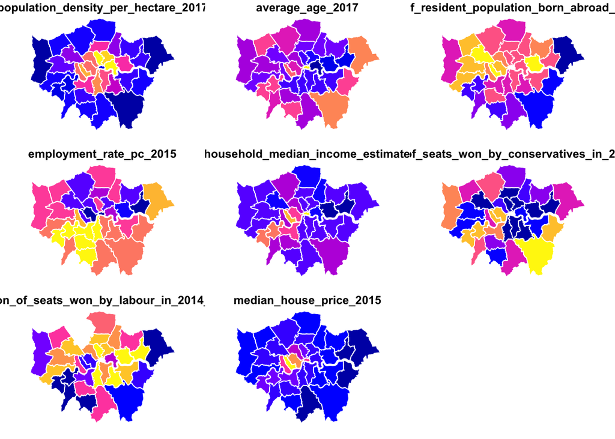

```r
lnd_boro = lnd_boro %>% select(gss, name, population_density_per_hectare_2017, average_age_2017, pc_of_resident_population_born_abroad_2015, employment_rate_pc_2015, modelled_household_median_income_estimates_2012_13, proportion_of_seats_won_by_conservatives_in_2014_election, proportion_of_seats_won_by_labour_in_2014_election, median_house_price_2015) %>% rename(id = gss)
plot(lnd_boro %>% select(-id,-name), border='white')
```

```r
# integrate missing data
# from https://data.gov.uk/dataset/248f5f04-23cf-4470-9216-0d0be9b877a8/london-borough-profiles-and-atlas/datafile/1e5d5226-a1a7-4097-afbf-d3bd39226c39/preview
#lnd_boro[lnd_boro$name == "Kensington and Chelsea", "gross_annual_pay_2016"] = 63620
```

### 4.2.1 Prep data

Find problematic variables.

```r
# get correlations
lnd_boro_corr = lnd_boro %>% st_drop_geometry() %>% select(-name,-id) %>% correlate(method='kendall') %>% stretch()
```

```
##
## Correlation method: 'kendall'
## Missing treated using: 'pairwise.complete.obs'
```

```r
# observe high correlations
lnd_boro_corr %>% filter(r > .5 | r < -.5)
```

```
## # A tibble: 10 x 3
##    x                                   y                                       r
##    <chr>                               <chr>                               <dbl>
##  1 population_density_per_hectare_2017 average_age_2017                   -0.514
##  2 average_age_2017                    population_density_per_hectare_20… -0.514
##  3 average_age_2017                    proportion_of_seats_won_by_conser…  0.586
##  4 average_age_2017                    proportion_of_seats_won_by_labour… -0.627
##  5 modelled_household_median_income_e… proportion_of_seats_won_by_conser…  0.501
##  6 proportion_of_seats_won_by_conserv… average_age_2017                    0.586
##  7 proportion_of_seats_won_by_conserv… modelled_household_median_income_…  0.501
##  8 proportion_of_seats_won_by_conserv… proportion_of_seats_won_by_labour… -0.697
##  9 proportion_of_seats_won_by_labour_… average_age_2017                   -0.627
## 10 proportion_of_seats_won_by_labour_… proportion_of_seats_won_by_conser… -0.697
```

```r
# remove Labour variable
lnd_boro = lnd_boro %>% select(-proportion_of_seats_won_by_labour_in_2014_election)
```

```r
lnd_boro_desc_stats = t(stat.desc(lnd_boro %>% st_drop_geometry() %>% select(-id,-name), norm=T))
lnd_boro_desc_stats
```

```
##                                                           nbr.val nbr.null
## population_density_per_hectare_2017                            33        0
## average_age_2017                                               33        0
## pc_of_resident_population_born_abroad_2015                     32        0
## employment_rate_pc_2015                                        33        0
## modelled_household_median_income_estimates_2012_13             33        0
## proportion_of_seats_won_by_conservatives_in_2014_election      32        5
## median_house_price_2015                                        33        0
##                                                           nbr.na          min
## population_density_per_hectare_2017                            0     21.84036
## average_age_2017                                               0     31.40000
## pc_of_resident_population_born_abroad_2015                     1     10.90000
## employment_rate_pc_2015                                        0     64.60000
## modelled_household_median_income_estimates_2012_13             0  28780.00000
## proportion_of_seats_won_by_conservatives_in_2014_election      1      0.00000
## median_house_price_2015                                        0 243500.00000
##                                                                    max
## population_density_per_hectare_2017                           155.6205
## average_age_2017                                               43.2000
## pc_of_resident_population_born_abroad_2015                     54.1000
## employment_rate_pc_2015                                        79.6000
## modelled_household_median_income_estimates_2012_13          63620.0000
## proportion_of_seats_won_by_conservatives_in_2014_election      85.0000
## median_house_price_2015                                   1200000.0000
##                                                                 range
## population_density_per_hectare_2017                          133.7801
## average_age_2017                                              11.8000
## pc_of_resident_population_born_abroad_2015                    43.2000
## employment_rate_pc_2015                                       15.0000
## modelled_household_median_income_estimates_2012_13         34840.0000
## proportion_of_seats_won_by_conservatives_in_2014_election     85.0000
## median_house_price_2015                                   956500.0000
##                                                                    sum
## population_density_per_hectare_2017                           2457.754
## average_age_2017                                              1200.400
## pc_of_resident_population_born_abroad_2015                    1168.400
## employment_rate_pc_2015                                       2399.600
## modelled_household_median_income_estimates_2012_13         1308190.000
## proportion_of_seats_won_by_conservatives_in_2014_election     1046.898
## median_house_price_2015                                   15360443.000
```

[output cut: 73 more lines]

```
## population_density_per_hectare_2017                        0.9229907
## average_age_2017                                           0.9747445
## pc_of_resident_population_born_abroad_2015                 0.9603938
## employment_rate_pc_2015                                    0.9631147
## modelled_household_median_income_estimates_2012_13         0.8804765
## proportion_of_seats_won_by_conservatives_in_2014_election  0.9128969
## median_house_price_2015                                    0.7935325
##                                                             normtest.p
## population_density_per_hectare_2017                       2.219048e-02
## average_age_2017                                          6.211098e-01
## pc_of_resident_population_born_abroad_2015                2.815670e-01
## employment_rate_pc_2015                                   3.158213e-01
## modelled_household_median_income_estimates_2012_13        1.723490e-03
## proportion_of_seats_won_by_conservatives_in_2014_election 1.340429e-02
## median_house_price_2015                                   2.435519e-05
```

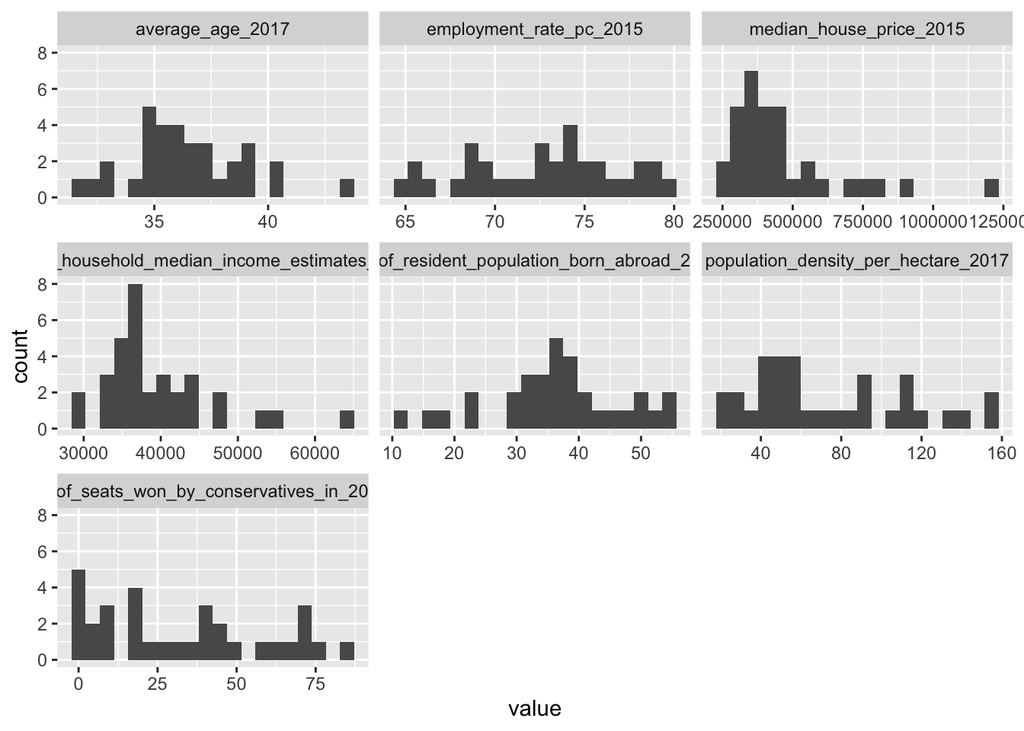

```r
# histograms to see normality
ggplot(gather(lnd_boro %>% st_drop_geometry() %>% select(-name,-id)), aes(value)) +
    geom_histogram(bins = 20) +
    facet_wrap(~key, scales = 'free_x')
```

The only variable whose skewness is a concern is `median_house_price_2015`. It will be normalised with log10.

```r
# normalise and scale
lnd_boro$median_house_price_2015_log10 = log10(lnd_boro$median_house_price_2015+1)
lnd_boro = lnd_boro %>% select(-median_house_price_2015)

# skewness is now acceptable
skewness(lnd_boro$median_house_price_2015_log10)
```

```
## [1] 0.9789651
```

Scale all numeric variables.

```r
lnd_boro_scaled = lnd_boro %>% mutate_if(is.numeric, scale) %>% mutate_if(is.numeric, range01)
lnd_boro_scaled %>% head(5)
```

```
## Simple feature collection with 5 features and 9 fields
## geometry type:  MULTIPOLYGON
## dimension:      XY
## bbox:           xmin: -0.4615023 ymin: 51.28676 xmax: 0.162358 ymax: 51.55968
## geographic CRS: WGS 84
##          id                 name population_density_per_hectare_2017
## 1 E09000021 Kingston upon Thames                           0.1886137
## 2 E09000008              Croydon                           0.1707267
## 3 E09000006              Bromley                           0.0000000
## 4 E09000018             Hounslow                           0.2028945
## 5 E09000009               Ealing                           0.3099149
##   average_age_2017 pc_of_resident_population_born_abroad_2015
## 1        0.4830508                                  0.4375000
## 2        0.4745763                                  0.4282407
## 3        0.7457627                                  0.1712963
```

[output cut: 20 more lines]

Multidimensional scaling of boroughs.

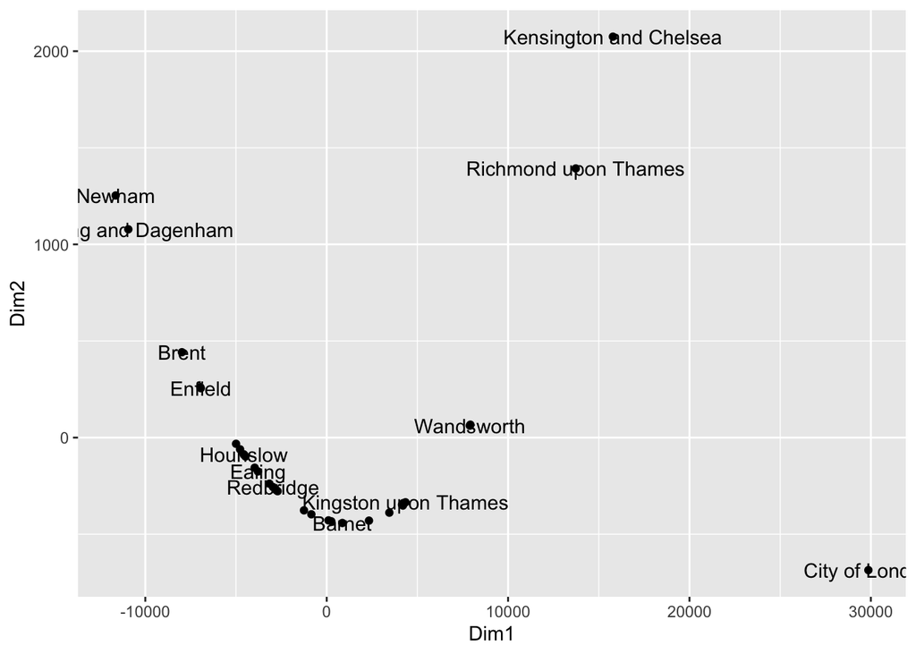

```r
mds <- lnd_boro %>% select(-name,-id) %>% st_drop_geometry() %>%
  dist() %>% cmdscale() %>% as_tibble()
colnames(mds) <- c("Dim1", "Dim2")
mds$name = lnd_boro_scaled$name

# plot MDS
ggplot(mds, aes(x=Dim1, y=Dim2)) +
  geom_point() +
  geom_text(
    label=mds$name,
    nudge_x = .25, nudge_y = .25,
    check_overlap = T
  )
```

```r
rm(mds)
```

### 4.2.2 Calc uniqueness

```r
#indata = lnd_boro_scaled %>% st_drop_geometry() %>% select(-name,-id)


#openxlsx::write.xlsx(lnd_boro_uniq %>% st_drop_geometry() %>% mutate_if(is.numeric, round, 4), 'analysis/london_boroughs_scaled_uniqueness.xlsx')
```

### 4.2.3 Viz uniqueness

```r
#lnd_boro_uniq %>% select(uniq) %>% plot(border = 'white', nbreaks = 10, breaks='pretty')
```

## 4.3 Countries (World Bank data)

## 4.4 EU (Eurostat data)

End of notebook